# 로지스틱 회귀분석

yoda

2017년 9월 3일

### 1. 데이터 로드 및 확인

```r
data1 <- read.csv("perfact2.csv")
str(data1)
```

```
## 'data.frame':    38912 obs. of  18 variables:
##  $ ID         : int  16186605 16186608 16186617 16186621 16186632 16186644 16186673 16186674 16186678 16186679 ...
##  $ POSTDATE   : Factor w/ 276 levels "2016-11-30","2016-12-01",..: 1 1 1 1 1 1 1 1 1 1 ...
##  $ MODEL      : Factor w/ 13 levels "A1303","A1332",..: 10 13 12 8 11 9 4 10 8 8 ...
##  $ GB         : Factor w/ 6 levels "128GB","16GB",..: 2 1 4 2 5 5 4 5 5 5 ...
##  $ KRNAME     : Factor w/ 13 levels "아이폰 3GS","아이폰 4",..: 9 12 11 7 13 10 4 9 7 7 ...
##  $ POSTPRICE  : int  390000 1030000 780000 230000 370000 510000 75000 420000 270000 300000 ...
##  $ CONTRACT   : Factor w/ 3 levels "모름","요금할인약정 가능",..: 1 1 1 1 1 1 1 1 1 1 ...
##  $ GUARANTEE  : Factor w/ 3 levels "무상 보증기간 남음 ",..: 1 1 1 3 1 2 2 3 2 2 ...
##  $ CHANGES    : Factor w/ 2 levels "유심기변","확정기변": 2 1 1 1 2 2 2 2 2 2 ...
##  $ CONDITIONS : Factor w/ 4 levels "미사용","상(새제품 수준/무흠집)",..: 2 1 1 2 2 2 3 3 2 3 ...
##  $ COMPONENT  : Factor w/ 3 levels "구성품 일부 누락",..: 1 1 1 1 1 1 1 1 3 1 ...
##  $ SOLD       : Factor w/ 2 levels "no","yes": 2 1 1 2 1 1 1 2 2 1 ...
##  $ RELDATE    : Factor w/ 10 levels "2009-11-28","2010-09-10",..: 7 9 9 6 8 7 4 7 6 6 ...
##  $ NEXTGENDATE: Factor w/ 10 levels "2010-09-10","2011-11-11",..: 7 9 9 6 8 7 4 7 6 6 ...
##  $ POSTRELGAP : int  404 40 40 761 204 404 1454 404 761 761 ...
##  $ POSTNEXTGAP: int  204 -128 -128 404 40 204 1132 204 404 404 ...
##  $ RELPRICE   : int  869000 1152800 869000 789800 699600 1130800 946000 999900 924000 924000 ...
##  $ FALLRATE   : num  55.1 10.7 10.2 70.9 47.1 54.9 92.1 58 70.8 67.5 ...
```

### 2. 연속형 변수 타입 변환(as.numeric) 및 표준화

```r
# 연속형 변수의 타입 변환
data1$POSTPRICE <- as.numeric(data1$POSTPRICE)
data1$POSTRELGAP <- as.numeric(data1$POSTRELGAP)
data1$POSTNEXTGAP <- as.numeric(data1$POSTNEXTGAP)
data1$RELPRICE   <- as.numeric(data1$RELPRICE)
data1$FALLRATE <- as.numeric(data1$FALLRATE)

# min, max를 이용하는 표준화 변환 함수 정의
normal <- function(x){
  return ((x-min(x)) / (max(x)-min(x)))
}

# 연속형 변수의 표준화
data1$POSTPRICE <- scale(data1$POSTPRICE)
data1$POSTRELGAP  <- scale(data1$POSTRELGAP)
data1$POSTNEXTGAP  <- scale(data1$POSTNEXTGAP)
data1$RELPRICE   <- scale(data1$RELPRICE)
data1$FALLRATE <- scale(data1$FALLRATE)
str(data1)
```

```
## 'data.frame':    38912 obs. of  18 variables:
##  $ ID         : int  16186605 16186608 16186617 16186621 16186632 16186644 16186673 16186674 16186678 16186679 ...
##  $ POSTDATE   : Factor w/ 276 levels "2016-11-30","2016-12-01",..: 1 1 1 1 1 1 1 1 1 1 ...
##  $ MODEL      : Factor w/ 13 levels "A1303","A1332",..: 10 13 12 8 11 9 4 10 8 8 ...
##  $ GB         : Factor w/ 6 levels "128GB","16GB",..: 2 1 4 2 5 5 4 5 5 5 ...
##  $ KRNAME     : Factor w/ 13 levels "아이폰 3GS","아이폰 4",..: 9 12 11 7 13 10 4 9 7 7 ...
##  $ POSTPRICE  : num [1:38912, 1] -0.485 2.085 1.081 -1.127 -0.565 ...
##   ..- attr(*, "scaled:center")= num 510770
##   ..- attr(*, "scaled:scale")= num 249052
##  $ CONTRACT   : Factor w/ 3 levels "모름","요금할인약정 가능",..: 1 1 1 1 1 1 1 1 1 1 ...
##  $ GUARANTEE  : Factor w/ 3 levels "무상 보증기간 남음 ",..: 1 1 1 3 1 2 2 3 2 2 ...
##  $ CHANGES    : Factor w/ 2 levels "유심기변","확정기변": 2 1 1 1 2 2 2 2 2 2 ...
##  $ CONDITIONS : Factor w/ 4 levels "미사용","상(새제품 수준/무흠집)",..: 2 1 1 2 2 2 3 3 2 3 ...
##  $ COMPONENT  : Factor w/ 3 levels "구성품 일부 누락",..: 1 1 1 1 1 1 1 1 3 1 ...
##  $ SOLD       : Factor w/ 2 levels "no","yes": 2 1 1 2 1 1 1 2 2 1 ...
##  $ RELDATE    : Factor w/ 10 levels "2009-11-28","2010-09-10",..: 7 9 9 6 8 7 4 7 6 6 ...
##  $ NEXTGENDATE: Factor w/ 10 levels "2010-09-10","2011-11-11",..: 7 9 9 6 8 7 4 7 6 6 ...
##  $ POSTRELGAP : num [1:38912, 1] -0.263 -1.214 -1.214 0.669 -0.785 ...
##   ..- attr(*, "scaled:center")= num 505
##   ..- attr(*, "scaled:scale")= num 383
##  $ POSTNEXTGAP: num [1:38912, 1] -0.227 -1.287 -1.287 0.411 -0.75 ...
##   ..- attr(*, "scaled:center")= num 275
##   ..- attr(*, "scaled:scale")= num 313
##  $ RELPRICE   : num [1:38912, 1] -0.59 1.15 -0.59 -1.08 -1.63 ...
##   ..- attr(*, "scaled:center")= num 965006
##   ..- attr(*, "scaled:scale")= num 162646
##  $ FALLRATE   : num [1:38912, 1] 0.3268 -1.7494 -1.7728 1.0657 -0.0473 ...
##   ..- attr(*, "scaled:center")= num 48.1
##   ..- attr(*, "scaled:scale")= num 21.4
```

종속변수 판매여부(SOLD)를 설명하는 변수인 POSTPRICE, POSTRELGAP, POSTNEXTGAP, RELPRICE, FALLRATE의 단위가 다르기 때문에 표준화를 해야한다. 표준화방법에는 scale()을 통한 z변환, min값과 max값을 이용하는 [0~1]변환이 있으며 여기서는 z변환을 사용한다.

### 3. 연속형 독립변수 간의 상관계수 확인

```r
# 연속형 변수만 따로 분리하여 데이터프레임 생성
co <- data.frame(data1$POSTPRICE, data1$POSTRELGAP, data1$POSTNEXTGAP, data1$RELPRICE, data1$FALLRATE)

# 변수간 상관계수 확인. 상관계수는 -1 ~ 1 사이의 값을 가지며
# 0.8 이상이면 다중공선성이 있을 확률이 높다.
cor(co)
```

```
##                   data1.POSTPRICE data1.POSTRELGAP data1.POSTNEXTGAP
## data1.POSTPRICE         1.0000000       -0.7983103        -0.7865832
## data1.POSTRELGAP       -0.7983103        1.0000000         0.9913452
## data1.POSTNEXTGAP      -0.7865832        0.9913452         1.0000000
## data1.RELPRICE          0.6294303       -0.2314999        -0.2243450
## data1.FALLRATE         -0.9128245        0.8920816         0.8806318
##                   data1.RELPRICE data1.FALLRATE
## data1.POSTPRICE        0.6294303     -0.9128245
## data1.POSTRELGAP      -0.2314999      0.8920816
## data1.POSTNEXTGAP     -0.2243450      0.8806318
## data1.RELPRICE         1.0000000     -0.2881986
## data1.FALLRATE        -0.2881986      1.0000000
```

상관계수 확인결과 변수 간의 상관계수가 0.8 이상인 값들이 있어 다중공선성을 의심해야 한다.

### 3. 로지스틱 회귀분석

```r
logit.fit <- glm(SOLD~KRNAME+GB+POSTPRICE+CONTRACT+GUARANTEE+CHANGES+CONDITIONS+COMPONENT+POSTRELGAP+POSTNEXTGAP+RELPRICE+FALLRATE, family=binomial(logit), data=data1)
summary(logit.fit)
```

```
##
## Call:
## glm(formula = SOLD ~ KRNAME + GB + POSTPRICE + CONTRACT + GUARANTEE +
##     CHANGES + CONDITIONS + COMPONENT + POSTRELGAP + POSTNEXTGAP +
##     RELPRICE + FALLRATE, family = binomial(logit), data = data1)
##
## Deviance Residuals:
##     Min       1Q   Median       3Q      Max
## -2.8534  -0.9685  -0.7167   1.2497   2.1336
##
## Coefficients:
##                                     Estimate Std. Error z value Pr(>|z|)
## (Intercept)                         1.148919   0.490698   2.341 0.019212
## KRNAME아이폰 4                      3.226151   0.631450   5.109 3.24e-07
## KRNAME아이폰 4S                     2.489235   0.584982   4.255 2.09e-05
## KRNAME아이폰 5                      0.471189   0.424121   1.111 0.266578
## KRNAME아이폰 5C                     2.416286   0.637278   3.792 0.000150
## KRNAME아이폰 5S                     1.670679   0.529247   3.157 0.001596
## KRNAME아이폰 6                      1.486150   0.553185   2.687 0.007220
## KRNAME아이폰 6 플러스               1.074577   0.515728   2.084 0.037196
## KRNAME아이폰 6S                    -2.900573   0.594390  -4.880 1.06e-06
## KRNAME아이폰 6S 플러스             -3.398642   0.678473  -5.009 5.46e-07
## KRNAME아이폰 7                     -3.197255   0.611975  -5.224 1.75e-07
## KRNAME아이폰 7 플러스              -4.214162   0.729292  -5.778 7.54e-09
## KRNAME아이폰 SE                    -2.240624   0.521322  -4.298 1.72e-05
## GB16GB                              0.999225   0.248319   4.024 5.72e-05
## GB256GB                            -0.954649   0.181087  -5.272 1.35e-07
## GB32GB                              0.991606   0.157268   6.305 2.88e-10
## GB64GB                              0.818854   0.127428   6.426 1.31e-10
## GB8GB                               3.274529   1.070580   3.059 0.002223
## POSTPRICE                           1.987502   0.239040   8.315  < 2e-16
## CONTRACT요금할인약정 가능           0.006362   0.029173   0.218 0.827372
## CONTRACT요금할인약정 불가           0.136767   0.039791   3.437 0.000588
## GUARANTEE무상 보증기간 만료         0.005984   0.038997   0.153 0.878040
## GUARANTEE미확인                    -0.029651   0.048259  -0.614 0.538937
## CHANGES확정기변                    -0.045264   0.035750  -1.266 0.205471
## CONDITIONS상(새제품 수준/무흠집)   -0.420076   0.038673 -10.862  < 2e-16
## CONDITIONS중 (생활흠집 외 양호)    -0.745446   0.048101 -15.497  < 2e-16
## CONDITIONS하(번인/잔상/파손)       -0.947287   0.091910 -10.307  < 2e-16
## COMPONENT단품 (기기본체만 있음)    -0.419691   0.062281  -6.739 1.60e-11
```

[output cut: 34 more lines]

```
## COMPONENT박스 및 모든 구성품 포함 *
## POSTRELGAP                        ***
## POSTNEXTGAP                       ***
## RELPRICE
## FALLRATE                          ***
## ---
## Signif. codes:  0 '***' 0.001 '**' 0.01 '*' 0.05 '.' 0.1 ' ' 1
##
## (Dispersion parameter for binomial family taken to be 1)
##
##     Null deviance: 50420  on 38911  degrees of freedom
## Residual deviance: 48041  on 38879  degrees of freedom
## AIC: 48107
##
## Number of Fisher Scoring iterations: 4
```

독립변수들이 많아질수록 변수들 간의 상관관계나 유의미한 변수들로 인해 성능이 나빠질 확률이 높다. 따라서 stepwise를 통해 종속 변수에 유의한 영향을 미치는 독립변수들을 선택하는 방법을 적용한다. 여기서 AIC는 주어진 데이터에 대한 통계 모형의 품질을 평가하는 척도이다. 따라서 STEPWISE를 토애 AIC값이 가장 작은 모형을 선택한다.

### 4. 다중공선성 확인

```r
library(car)
vif(logit.fit)
```

```
##                     GVIF Df GVIF^(1/(2*Df))
## KRNAME      9.792190e+05 12        1.776724
## GB          8.258081e+02  5        1.957438
## POSTPRICE   4.402974e+02  1       20.983266
## CONTRACT    1.677588e+00  2        1.138076
## GUARANTEE   3.019627e+00  2        1.318221
## CHANGES     1.687464e+00  1        1.299024
## CONDITIONS  2.694903e+00  3        1.179661
## COMPONENT   1.645506e+00  2        1.132596
## POSTRELGAP  1.557960e+04  1      124.818267
## POSTNEXTGAP 1.040601e+04  1      102.009872
## RELPRICE    1.677521e+02  1       12.951916
## FALLRATE    3.316055e+02  1       18.210038
```

### 5. 최적의 결과를 얻기 위해 stepwise 실행

```r
logit.step <- step(logit.fit, direction="both")
```

```
## Start:  AIC=48107.28
## SOLD ~ KRNAME + GB + POSTPRICE + CONTRACT + GUARANTEE + CHANGES +
##     CONDITIONS + COMPONENT + POSTRELGAP + POSTNEXTGAP + RELPRICE +
##     FALLRATE
##
##               Df Deviance   AIC
## - GUARANTEE    2    48042 48104
## - RELPRICE     1    48041 48105
## - CHANGES      1    48043 48107
## <none>              48041 48107
## - CONTRACT     2    48055 48117
## - COMPONENT    2    48089 48151
## - POSTNEXTGAP  1    48101 48165
## - POSTRELGAP   1    48105 48169
## - POSTPRICE    1    48114 48178
## - KRNAME      12    48204 48246
## - GB           5    48198 48254
## - FALLRATE     1    48192 48256
## - CONDITIONS   3    48301 48361
##
## Step:  AIC=48104
## SOLD ~ KRNAME + GB + POSTPRICE + CONTRACT + CHANGES + CONDITIONS +
##     COMPONENT + POSTRELGAP + POSTNEXTGAP + RELPRICE + FALLRATE
##
##               Df Deviance   AIC
## - RELPRICE     1    48042 48102
## - CHANGES      1    48044 48104
## <none>              48042 48104
## + GUARANTEE    2    48041 48107
## - CONTRACT     2    48056 48114
## - COMPONENT    2    48090 48148
## - POSTNEXTGAP  1    48102 48162
## - POSTRELGAP   1    48105 48165
## - POSTPRICE    1    48115 48175
## - KRNAME      12    48205 48243
## - GB           5    48200 48252
## - FALLRATE     1    48194 48254
## - CONDITIONS   3    48306 48362
##
## Step:  AIC=48102.08
```

[output cut: 21 more lines]

```
##
##               Df Deviance   AIC
## <none>              48044 48102
## + CHANGES      1    48042 48102
## + RELPRICE     1    48044 48104
## + GUARANTEE    2    48043 48105
## - CONTRACT     2    48064 48118
## - COMPONENT    2    48092 48146
## - POSTPRICE    1    48118 48174
## - POSTNEXTGAP  1    48158 48214
## - POSTRELGAP   1    48168 48224
## - FALLRATE     1    48196 48252
## - GB           5    48205 48253
## - KRNAME      12    48229 48263
## - CONDITIONS   3    48317 48369
```

최종적으로 선택된 설명변수는 다음과 같다.

```r
formula(logit.step)
```

```
## SOLD ~ KRNAME + GB + POSTPRICE + CONTRACT + CONDITIONS + COMPONENT +
##     POSTRELGAP + POSTNEXTGAP + FALLRATE
```

### 6. STEPWISE를 통해 최종적으로 선택된 변수로 로지스틱회귀분석 실행

```r
logit.best <- glm(formula(logit.step), family=binomial, data=data1)
summary(logit.best)
```

```
##
## Call:
## glm(formula = formula(logit.step), family = binomial, data = data1)
##
## Deviance Residuals:
##     Min       1Q   Median       3Q      Max
## -2.8999  -0.9691  -0.7167   1.2494   2.1355
##
## Coefficients:
##                                     Estimate Std. Error z value Pr(>|z|)
## (Intercept)                         1.154079   0.476943   2.420 0.015532
## KRNAME아이폰 4                      3.344205   0.540355   6.189 6.06e-10
## KRNAME아이폰 4S                     2.581446   0.535496   4.821 1.43e-06
## KRNAME아이폰 5                      0.492002   0.423320   1.162 0.245135
## KRNAME아이폰 5C                     2.491648   0.581761   4.283 1.84e-05
## KRNAME아이폰 5S                     1.735997   0.506861   3.425 0.000615
## KRNAME아이폰 6                      1.546244   0.535063   2.890 0.003854
## KRNAME아이폰 6 플러스               1.077300   0.513576   2.098 0.035937
## KRNAME아이폰 6S                    -2.999261   0.506871  -5.917 3.27e-09
## KRNAME아이폰 6S 플러스             -3.533672   0.527958  -6.693 2.19e-11
## KRNAME아이폰 7                     -3.295990   0.533067  -6.183 6.29e-10
## KRNAME아이폰 7 플러스              -4.356321   0.587035  -7.421 1.16e-13
## KRNAME아이폰 SE                    -2.285697   0.502436  -4.549 5.38e-06
## GB16GB                              1.065918   0.119209   8.942  < 2e-16
## GB256GB                            -0.999131   0.138568  -7.210 5.58e-13
## GB32GB                              1.030663   0.100136  10.293  < 2e-16
## GB64GB                              0.847164   0.082787  10.233  < 2e-16
## GB8GB                               3.488374   0.850280   4.103 4.08e-05
## POSTPRICE                           2.001677   0.238546   8.391  < 2e-16
## CONTRACT요금할인약정 가능           0.000934   0.028278   0.033 0.973652
## CONTRACT요금할인약정 불가           0.151163   0.038579   3.918 8.92e-05
## CONDITIONS상(새제품 수준/무흠집)   -0.429006   0.037931 -11.310  < 2e-16
## CONDITIONS중 (생활흠집 외 양호)    -0.753979   0.047190 -15.978  < 2e-16
## CONDITIONS하(번인/잔상/파손)       -0.953769   0.091578 -10.415  < 2e-16
## COMPONENT단품 (기기본체만 있음)    -0.419063   0.062095  -6.749 1.49e-11
## COMPONENT박스 및 모든 구성품 포함  -0.054447   0.026749  -2.035 0.041807
## POSTRELGAP                        -10.508161   0.983653 -10.683  < 2e-16
## POSTNEXTGAP                         8.357671   0.814235  10.264  < 2e-16
## FALLRATE                            2.393040   0.202075  11.842  < 2e-16
##
```

[output cut: 24 more lines]

```
## COMPONENT단품 (기기본체만 있음)   ***
## COMPONENT박스 및 모든 구성품 포함 *
## POSTRELGAP                        ***
## POSTNEXTGAP                       ***
## FALLRATE                          ***
## ---
## Signif. codes:  0 '***' 0.001 '**' 0.01 '*' 0.05 '.' 0.1 ' ' 1
##
## (Dispersion parameter for binomial family taken to be 1)
##
##     Null deviance: 50420  on 38911  degrees of freedom
## Residual deviance: 48044  on 38883  degrees of freedom
## AIC: 48102
##
## Number of Fisher Scoring iterations: 4
```

```r
exp(logit.best$coefficients)
```

```
##                       (Intercept)                    KRNAME아이폰 4
##                      3.171100e+00                      2.833803e+01
##                   KRNAME아이폰 4S                    KRNAME아이폰 5
##                      1.321623e+01                      1.635587e+00
##                   KRNAME아이폰 5C                   KRNAME아이폰 5S
##                      1.208116e+01                      5.674583e+00
##                    KRNAME아이폰 6             KRNAME아이폰 6 플러스
##                      4.693807e+00                      2.936739e+00
##                   KRNAME아이폰 6S            KRNAME아이폰 6S 플러스
##                      4.982390e-02                      2.919750e-02
##                    KRNAME아이폰 7             KRNAME아이폰 7 플러스
##                      3.703135e-02                      1.282548e-02
##                   KRNAME아이폰 SE                            GB16GB
##                      1.017031e-01                      2.903502e+00
##                           GB256GB                            GB32GB
##                      3.681993e-01                      2.802924e+00
##                            GB64GB                             GB8GB
##                      2.333020e+00                      3.273270e+01
##                         POSTPRICE         CONTRACT요금할인약정 가능
##                      7.401457e+00                      1.000934e+00
##         CONTRACT요금할인약정 불가  CONDITIONS상(새제품 수준/무흠집)
##                      1.163187e+00                      6.511560e-01
##   CONDITIONS중 (생활흠집 외 양호)      CONDITIONS하(번인/잔상/파손)
##                      4.704906e-01                      3.852863e-01
##   COMPONENT단품 (기기본체만 있음) COMPONENT박스 및 모든 구성품 포함
##                      6.576629e-01                      9.470091e-01
##                        POSTRELGAP                       POSTNEXTGAP
##                      2.731265e-05                      4.262755e+03
##                          FALLRATE
##                      1.094672e+01
```

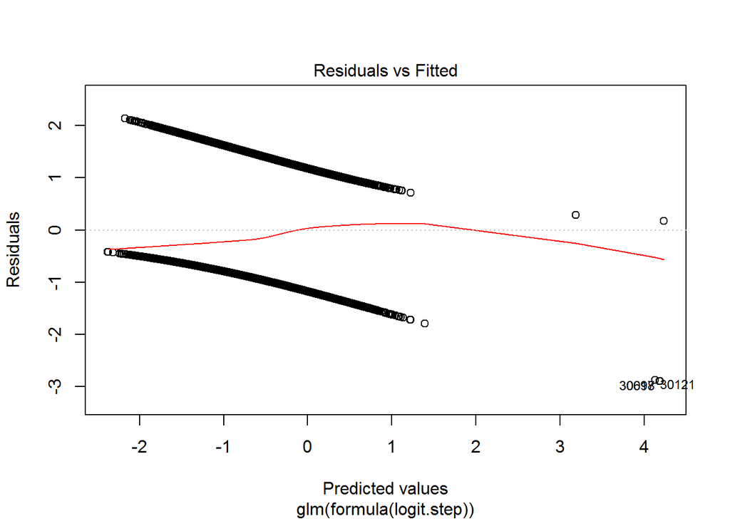

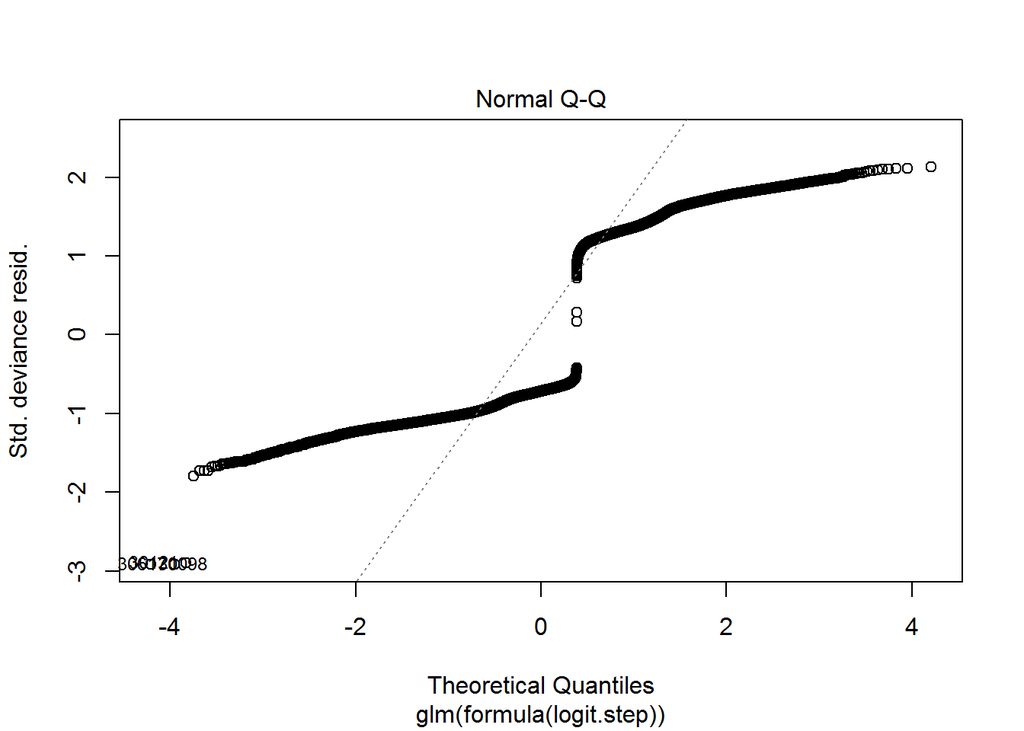

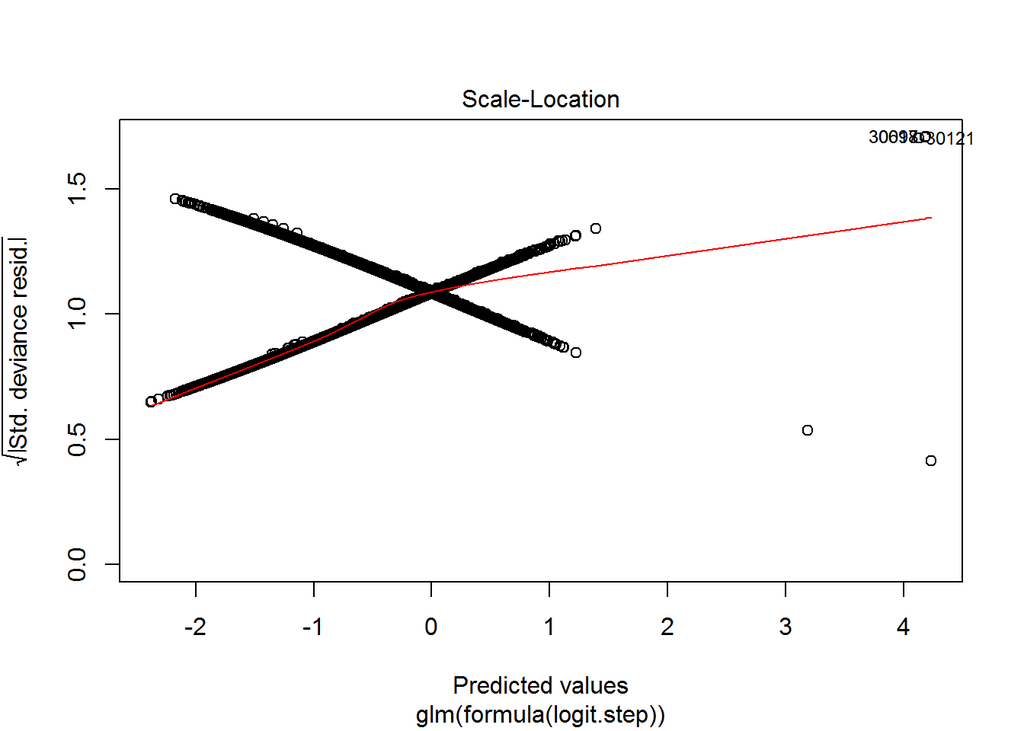

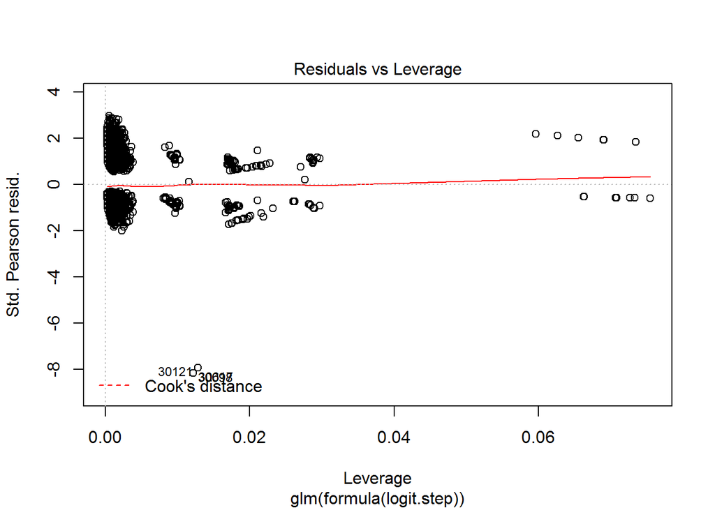

```r
plot(logit.best)
```

예를 들어 다른변수들이 고정되었을 때 아이폰 4면은 아이폰 3보다 odds ratio(오즈비=성공확률)가 약 28배 정도이다.